# PW8 Machine Learning

Sandrine NEANG

07/12/2022

K-means  
Question 1 : Download the dataset: Ligue1 2017-2018 and import it into R. Put the argument row.names to 1.

```r
ligue1 = read.csv("C:/Users/sandr/OneDrive/Documents/Scolarité/ESILV/M1 A4/S7/Machine Learning/TDs/Datas/ligue1_17_18.csv", row.names=1, sep=";")
head(ligue1)
```

```
##           Points Wins Draws Loses Goals.scored Goals.conceded Difference.goals
## Paris-SG      93   29     6     3          108             29               79
## Monaco        80   24     8     6           85             45               40
## Lyon          78   23     9     6           87             43               44
## Marseille     77   22    11     5           80             47               33
## Rennes        58   16    10    12           50             44                6
## Bordeaux      55   16     7    15           53             48                5
##           Points.per.game red.cards yellow.cards clean.sheets.percentage
## Paris-SG             2.45         6           66                      47
## Monaco               2.11         3           70                      37
## Lyon                 2.05         2           70                      39
## Marseille            2.03         3           79                      37
## Rennes               1.53         5           63                      26
## Bordeaux             1.45         2           73                      26
##           failed.to.score.percentage shots.per.match.average
## Paris-SG                           8                   16.05
## Monaco                            11                   15.68
## Lyon                              11                   14.55
## Marseille                          8                   12.79
## Rennes                            13                   12.47
## Bordeaux                          37                   12.34
##           shots.on.goal.per.match.average ball.possession.per.game.average
## Paris-SG                             6.74                            63.34
## Monaco                               3.18                            57.68
## Lyon                                 6.08                            56.37
## Marseille                            3.66                            55.89
## Rennes                               4.08                            52.59
## Bordeaux                             4.74                            51.76
##           sum.offside.in.attack sum.offside.in.defense corners.per.game.average
## Paris-SG                     98                     99                     6.71
## Monaco                       93                     90                     6.39
## Lyon                         89                     76                     5.74
## Marseille                    87                     68                     5.34
## Rennes                       86                     57                     5.32
## Bordeaux                     84                     39                     5.13
##           fouls.for.sum fouls.against.sum
## Paris-SG            139               105
## Monaco              115               112
## Lyon                114               107
## Marseille           112                85
## Rennes              110               117
## Bordeaux            109               109
```

**Question 2 : Print the two rows of the dataset and the total number of features in this dataset.**

```r
library(knitr)
knitr::kable(head(ligue1[1:2,] ), "simple")
```

[output not shown]

```r
pointscards <- ligue1[, c("Points", "yellow.cards")]

knitr::kable(head(pointscards,"Points","yellow.cards"))
```

|  | Points | yellow.cards |
| --- | --- | --- |
| Paris-SG | 93 | 66 |
| Monaco | 80 | 70 |
| Lyon | 78 | 70 |
| Marseille | 77 | 79 |
| Rennes | 58 | 63 |
| Bordeaux | 55 | 73 |
| Saint-Etienne | 55 | 72 |
| Nice | 54 | 83 |
| Nantes | 52 | 63 |
| Montpellier | 51 | 72 |
| Dijon | 48 | 69 |
| Guingamp | 47 | 65 |
| Amiens | 45 | 72 |
| Angers | 41 | 69 |
| Strasbourg | 38 | 72 |
| Caen | 38 | 67 |
| Lille | 38 | 60 |
| Toulouse | 37 | 90 |
| Troyes | 33 | 77 |
| Metz | 26 | 78 |

**Question 4 : Apply k-means on pointsCards. Chose k=2 clusters and put the number of iterations to 20. Store your results into km.**

```r
set.seed(123)
km=kmeans(pointscards,2)
```

**Question 5 : Print and describe what is inside km.**

```r
print(km)
```

```
## K-means clustering with 2 clusters of sizes 4, 16
##
## Cluster means:
##   Points yellow.cards
## 1  82.00      71.2500
## 2  44.75      71.5625
##
## Clustering vector:
##      Paris-SG        Monaco          Lyon     Marseille        Rennes
##             1             1             1             1             2
##      Bordeaux Saint-Etienne          Nice        Nantes   Montpellier
##             2             2             2             2             2
##         Dijon      Guingamp        Amiens        Angers    Strasbourg
##             2             2             2             2             2
##          Caen         Lille      Toulouse        Troyes          Metz
##             2             2             2             2             2
##
## Within cluster sum of squares by cluster:
## [1]  256.750 2180.938
##  (between_SS / total_SS =  64.6 %)
##
## Available components:
##
## [1] "cluster"      "centers"      "totss"        "withinss"     "tot.withinss"
## [6] "betweenss"    "size"         "iter"         "ifault"
```

**Question 6 : What are the coordinates of the centers of the clusters?**

```r
print(km$centers)
```

```
##   Points yellow.cards
## 1  82.00      71.2500
## 2  44.75      71.5625
```

**Question 7 : Plot the data (Yellow.cards vs Points). Color the points corresponding to their cluster.**

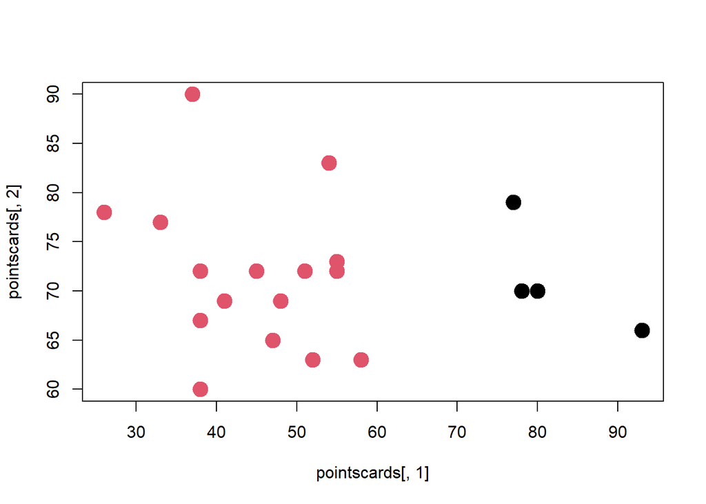

```r
plot(pointscards[, 1], pointscards[, 2],col=km$cluster,pch=20,cex=3)
```

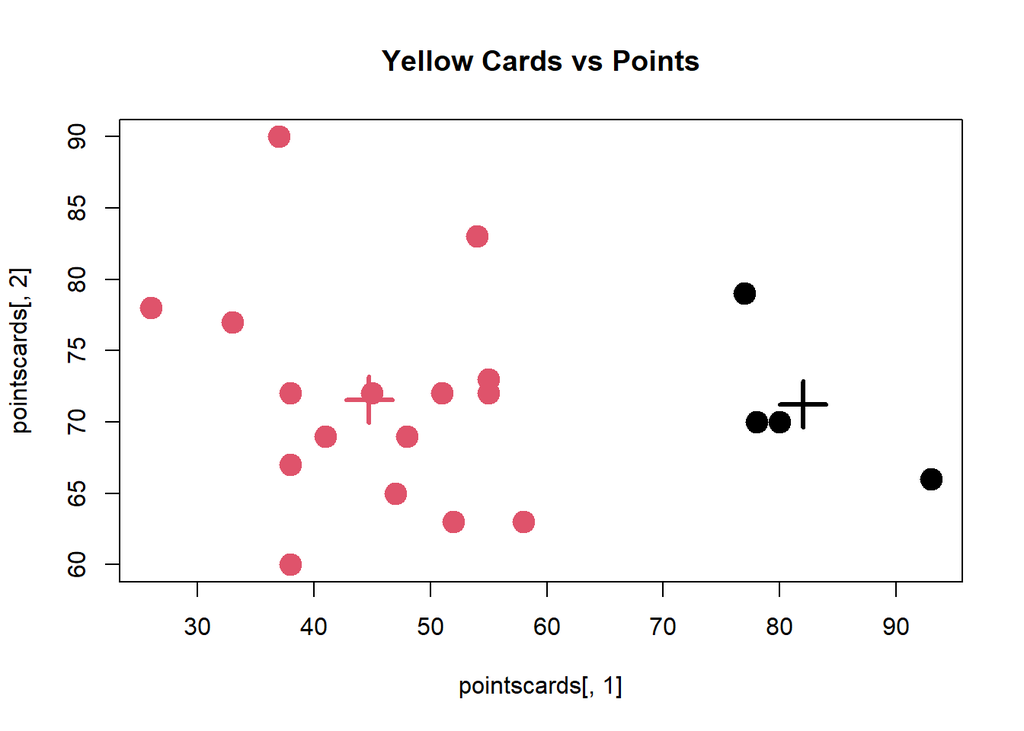

```r
plot(pointscards[, 1], pointscards[, 2],col=km$cluster,pch=20,cex=3)
points(km$centers,col=1:2,pch=3,cex=3,lwd=3, title(main = "Yellow Cards vs Points"))
```

**Question 9 : Re-run k-means on pointsCards using 3 and 4 clusters and store the results into km3 and km4 respectively. Visualize the results like in question 7 and 8.**

```r
km3=kmeans(pointscards,3)
print(km3)
```

```
## K-means clustering with 3 clusters of sizes 7, 4, 9
##
## Cluster means:
##     Points yellow.cards
## 1 35.85714     73.28571
## 2 82.00000     71.25000
## 3 51.66667     70.22222
##
## Clustering vector:
##      Paris-SG        Monaco          Lyon     Marseille        Rennes
##             2             2             2             2             3
##      Bordeaux Saint-Etienne          Nice        Nantes   Montpellier
##             3             3             3             3             3
##         Dijon      Guingamp        Amiens        Angers    Strasbourg
##             3             3             3             1             1
##          Caen         Lille      Toulouse        Troyes          Metz
##             1             1             1             1             1
##
## Within cluster sum of squares by cluster:
## [1] 698.2857 256.7500 461.5556
##  (between_SS / total_SS =  79.4 %)
##
## Available components:
##
## [1] "cluster"      "centers"      "totss"        "withinss"     "tot.withinss"
## [6] "betweenss"    "size"         "iter"         "ifault"
```

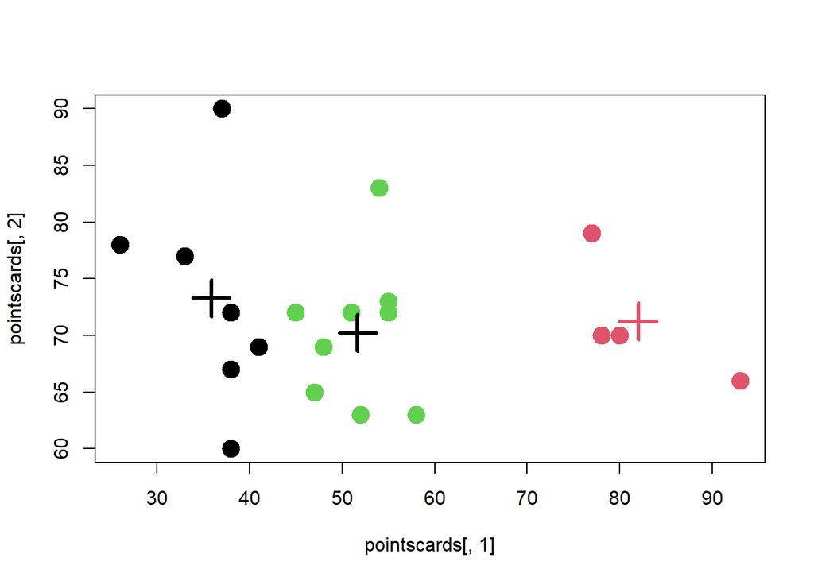

```r
plot(pointscards[, 1], pointscards[, 2],col=km3$cluster,pch=20,cex=3)
points(km3$centers,col=1:2,pch=3,cex=3,lwd=3)
```

```r
km4=kmeans(pointscards,4)
print(km4)
```

```
## K-means clustering with 4 clusters of sizes 3, 7, 4, 6
##
## Cluster means:
##     Points yellow.cards
## 1 32.00000     81.66667
## 2 53.28571     70.71429
## 3 82.00000     71.25000
## 4 41.16667     67.50000
##
## Clustering vector:
##      Paris-SG        Monaco          Lyon     Marseille        Rennes
##             3             3             3             3             2
##      Bordeaux Saint-Etienne          Nice        Nantes   Montpellier
##             2             2             2             2             2
##         Dijon      Guingamp        Amiens        Angers    Strasbourg
##             2             4             4             4             4
##          Caen         Lille      Toulouse        Troyes          Metz
##             4             4             1             1             1
##
## Within cluster sum of squares by cluster:
## [1] 166.6667 344.8571 256.7500 184.3333
##  (between_SS / total_SS =  86.2 %)
##
## Available components:
##
## [1] "cluster"      "centers"      "totss"        "withinss"     "tot.withinss"
## [6] "betweenss"    "size"         "iter"         "ifault"
```

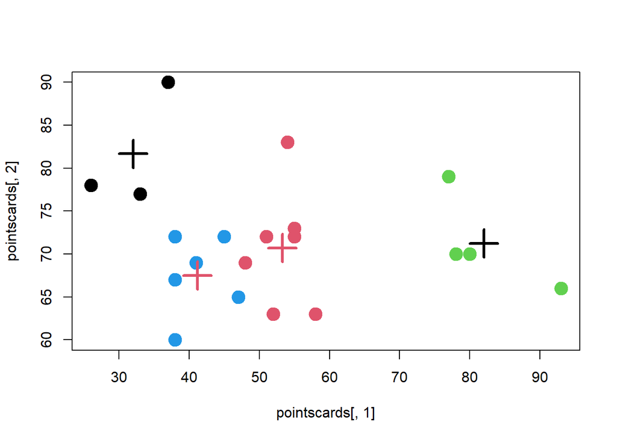

```r
plot(pointscards[, 1], pointscards[, 2],col=km4$cluster,pch=20,cex=3)
points(km4$centers,col=1:2,pch=3,cex=3,lwd=3)
```

**Question 10 : Visualize the “within groups sum of squares” of the k-means clustering results.**

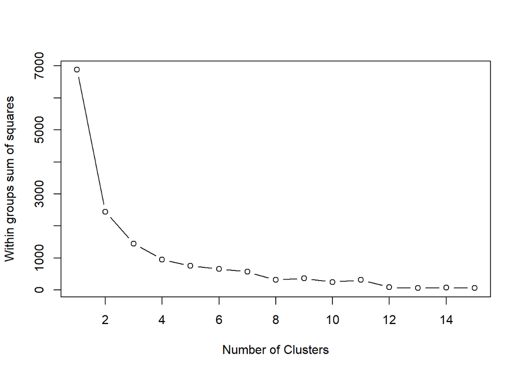

```r
mydata=pointscards
wss=(nrow(mydata)-1)*sum(apply(mydata,2,var))
for (i in 2:15) wss[i]=sum(kmeans(mydata,centers=i)$withinss)
plot(1:15, wss, type="b", xlab="Number of Clusters",ylab="Within groups sum of squares")
```

**Question 11 : Modify the code of the previous question in order to visualize the ‘between_SS / total_SS’. Interpret the results.**

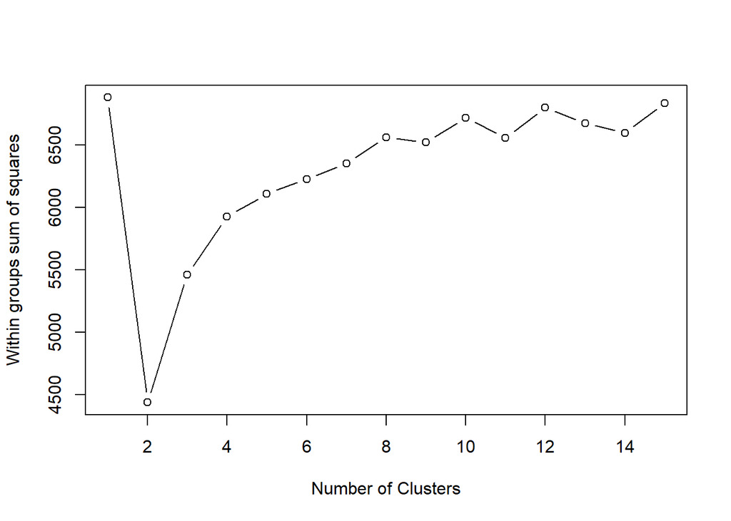

```r
mydata=pointscards
wss = (nrow(mydata)-1)*sum(apply(mydata,2,var))
for (i in 2:15) wss[i]=sum(kmeans(mydata,centers=i)$betweenss)
plot(1:15, wss, type="b", xlab="Number of Clusters",ylab="Within groups sum of squares")
```

**Question 12 : Now we consider all features. Scale the dataset and transform it to a data frame again. Store the scaled dataset into ligue1_scaled.**

```r
ligue1_scaled=scale(ligue1[,-(1)])
```

**Question 13 : Apply kmeans() on ligue1 and ligue1_scaled using 3 clusters and 20 iterations. Store the results into km.ligue1 and km.ligue1.scaled respectively.**

```r
set.seed(123)
km.ligue1=kmeans(ligue1[,-(1)],centers=3, iter.max = 20)
km.ligue1.scaled=kmeans(ligue1_scaled,centers=3, iter.max = 20)
```

**Question 14 : How many observations there are in each cluster of km.ligue1 and km.ligue1.sclaed ?**

```r
table(km.ligue1$cluster)
```

```
##
## 1 2 3
## 8 8 4
```

```r
table(km.ligue1.scaled$cluster)
```

```
##
## 1 2 3
## 4 8 8
```

**Question 15 : Apply PCA on ligue1 dataset and store your results in pcaligue1. Do we need to apply PCA on the scaled dataset?**

```r
library(FactoMineR)
library(factoextra)
pcaligue1=PCA(ligue1)
```

[figure not shown]

[figure not shown]

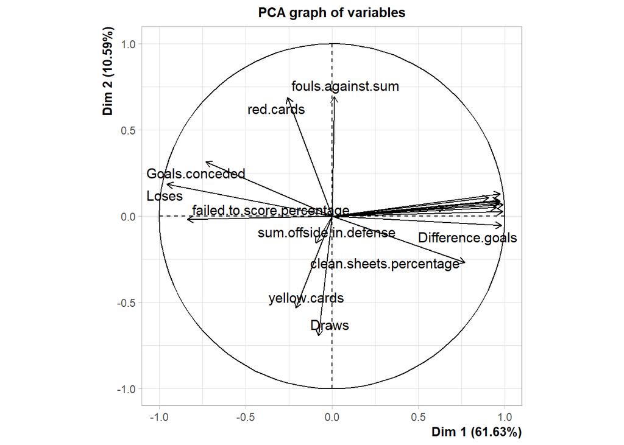

```
## **Results for the Principal Component Analysis (PCA)**
## The analysis was performed on 20 individuals, described by 19 variables
## *The results are available in the following objects:
##
##    name               description
## 1  "$eig"             "eigenvalues"
## 2  "$var"             "results for the variables"
## 3  "$var$coord"       "coord. for the variables"
## 4  "$var$cor"         "correlations variables - dimensions"
## 5  "$var$cos2"        "cos2 for the variables"
## 6  "$var$contrib"     "contributions of the variables"
## 7  "$ind"             "results for the individuals"
## 8  "$ind$coord"       "coord. for the individuals"
## 9  "$ind$cos2"        "cos2 for the individuals"
## 10 "$ind$contrib"     "contributions of the individuals"
## 11 "$call"            "summary statistics"
## 12 "$call$centre"     "mean of the variables"
## 13 "$call$ecart.type" "standard error of the variables"
## 14 "$call$row.w"      "weights for the individuals"
## 15 "$call$col.w"      "weights for the variables"
```

```r
PCA(ligue1_scaled)
```

**Question 17 : Visualize the teams on the first two principal components and color them with respect to their cluster.**

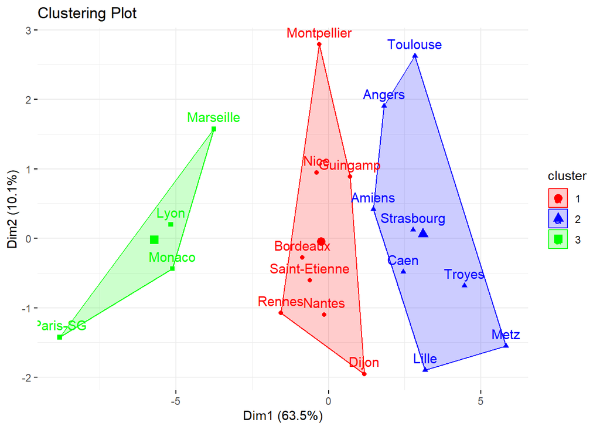

```r
fviz_cluster(km.ligue1, data = ligue1,
             palette = c("red", "blue", "green"),
             ggtheme = theme_minimal(),
             main = "Clustering Plot")
```

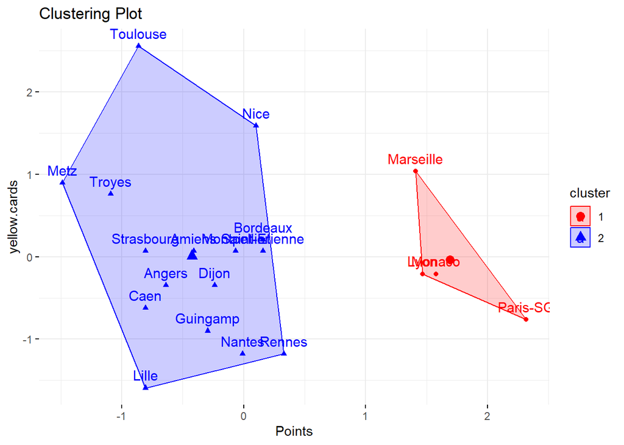

```r
fviz_cluster(km, data = pointscards,
             palette = c("red", "blue"),
             ggtheme = theme_minimal(),
             main = "Clustering Plot"
)
```

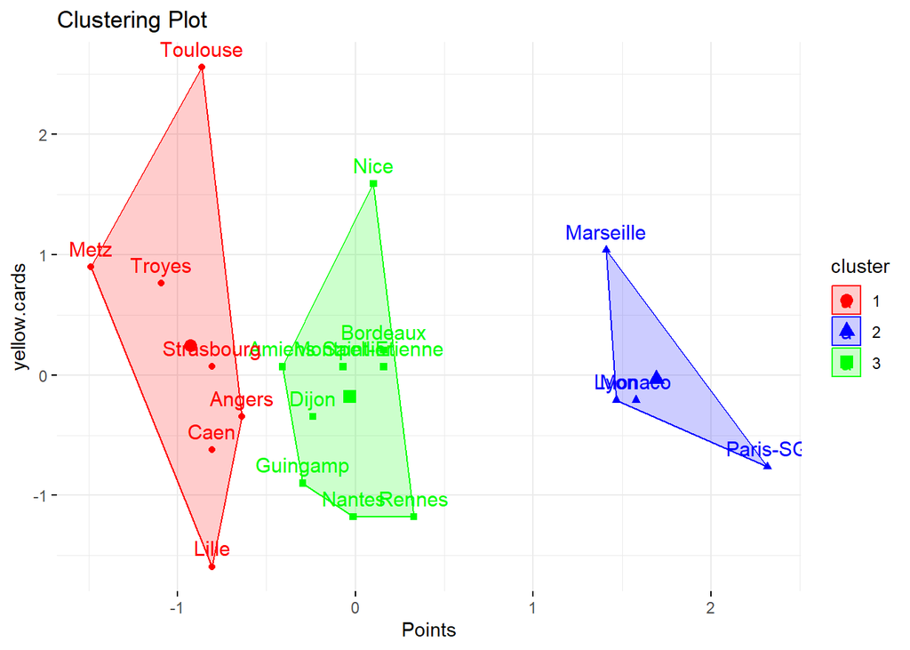

```r
fviz_cluster(km3, data = pointscards,
             palette = c("red", "blue", "green"),
             ggtheme = theme_minimal(),
             main = "Clustering Plot"
)
```

Hierarchical Clustering  
Question 1 : Load the file “customer.csv” and name the data : “customer_data”.

```r
customer_data = read.csv("C:/Users/sandr/OneDrive/Documents/Scolarité/ESILV/M1 A4/S7/Machine Learning/TDs/Datas/customer.csv")
```

**Question 2 : Show its summary and structure.**

```r
summary(customer_data)
```

```
##        ID          Visit.Time   Average.Expense      Sex
##  Min.   : 1.00   Min.   : 1.0   Min.   : 4.50   Min.   :0.0000
##  1st Qu.:15.75   1st Qu.: 5.0   1st Qu.:10.82   1st Qu.:0.0000
##  Median :30.50   Median : 7.5   Median :16.00   Median :1.0000
##  Mean   :30.50   Mean   : 8.4   Mean   :17.06   Mean   :0.6833
##  3rd Qu.:45.25   3rd Qu.:12.0   3rd Qu.:24.90   3rd Qu.:1.0000
##  Max.   :60.00   Max.   :18.0   Max.   :33.70   Max.   :1.0000
##       Age
##  Min.   : 8.00
##  1st Qu.:15.00
##  Median :20.50
##  Mean   :21.43
##  3rd Qu.:27.00
##  Max.   :47.00
```

```r
head(customer_data)
```

```
##   ID Visit.Time Average.Expense Sex Age
## 1  1          3             5.7   0  10
## 2  2          5            14.5   0  27
## 3  3         16            33.5   0  32
## 4  4          5            15.9   0  30
## 5  5         16            24.9   0  23
## 6  6          3            12.0   0  15
```

```r
str(customer_data)
```

```
## 'data.frame':    60 obs. of  5 variables:
##  $ ID             : int  1 2 3 4 5 6 7 8 9 10 ...
##  $ Visit.Time     : int  3 5 16 5 16 3 12 14 6 3 ...
##  $ Average.Expense: num  5.7 14.5 33.5 15.9 24.9 12 28.5 18.8 23.8 5.3 ...
##  $ Sex            : int  0 0 0 0 0 0 0 0 0 0 ...
##  $ Age            : int  10 27 32 30 23 15 33 27 16 11 ...
```

**Question 3 : Check that there is no missing data and then normalize the customer data into the same scale.**

```r
is.na(customer_data)
```

[output not shown]

[output cut: 46 more lines]

```r
customer <- scale(customer_data[,-1])
```

**Question 4 : Compute the Hopkins statistic and evaluate the cluster structure.**

```r
library(factoextra)
res <- get_clust_tendency(customer_data, n = nrow(customer_data)-1, graph = FALSE)
res$hopkins_stat
```

```
## [1] 0.6014905
```

**Question 5 : Estimate the optimal number of cluster for the customer data using NbClust function.**

```r
library(NbClust)
customer_scaled <- scale(customer_data)

res.nbclust <- NbClust(customer_scaled, distance = "euclidean",
                       min.nc = 2, max.nc = 9,
                       method = "complete", index ="all")
```

[output not shown]

[output cut: 12 more lines]

[output not shown]

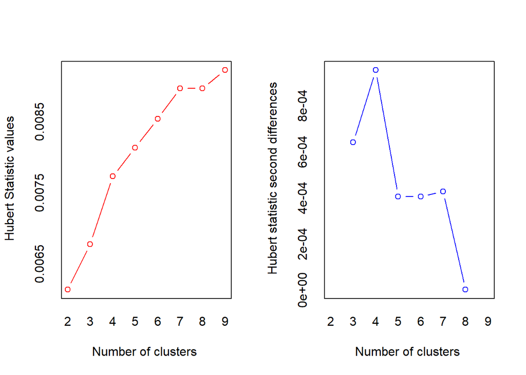

```
## *** : The Hubert index is a graphical method of determining the number of clusters.
##                 In the plot of Hubert index, we seek a significant knee that corresponds to a
##                 significant increase of the value of the measure i.e the significant peak in Hubert
##                 index second differences plot.
##
```

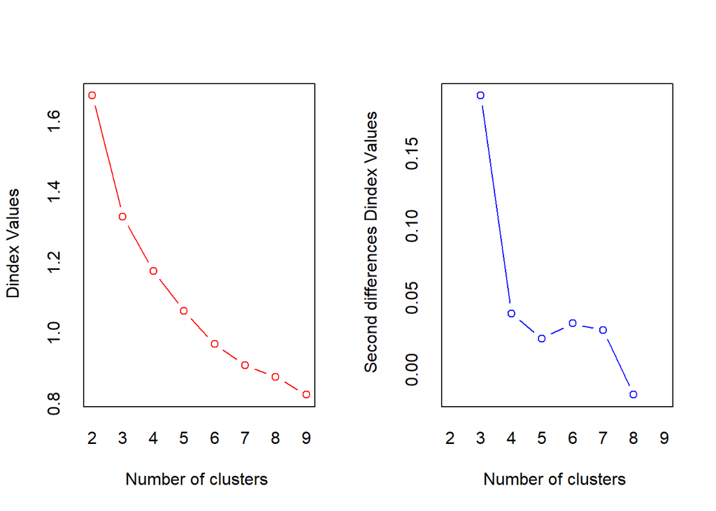

```
## *** : The D index is a graphical method of determining the number of clusters.
##                 In the plot of D index, we seek a significant knee (the significant peak in Dindex
##                 second differences plot) that corresponds to a significant increase of the value of
##                 the measure.
##
## * Among all indices:
## * 1 proposed 2 as the best number of clusters
## * 10 proposed 3 as the best number of clusters
## * 1 proposed 4 as the best number of clusters
## * 5 proposed 5 as the best number of clusters
## * 1 proposed 6 as the best number of clusters
## * 3 proposed 7 as the best number of clusters
## * 1 proposed 8 as the best number of clusters
## * 1 proposed 9 as the best number of clusters
##
##                    ***** Conclusion *****
##
## * According to the majority rule, the best number of clusters is  3
##
##
```

```
## Among all indices:
## ===================
## * 2 proposed  0 as the best number of clusters
## * 1 proposed  1 as the best number of clusters
## * 1 proposed  2 as the best number of clusters
## * 10 proposed  3 as the best number of clusters
## * 1 proposed  4 as the best number of clusters
## * 5 proposed  5 as the best number of clusters
## * 1 proposed  6 as the best number of clusters
## * 3 proposed  7 as the best number of clusters
## * 1 proposed  8 as the best number of clusters
## * 1 proposed  9 as the best number of clusters
##
## Conclusion
## =========================
## * According to the majority rule, the best number of clusters is  3 .
```

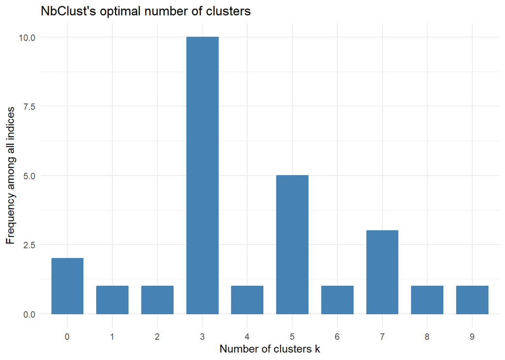

```r
factoextra::fviz_nbclust(res.nbclust) + theme_minimal() + ggtitle("NbClust's optimal number of clusters")
```

**Question 6 : Use agglomerative hierarchical clustering to cluster the customer data.**

```r
hc <- hclust(dist(customer, method = "euclidean"), method = "ward.D2")
hc
```

```
##
## Call:
## hclust(d = dist(customer, method = "euclidean"), method = "ward.D2")
##
## Cluster method   : ward.D2
## Distance         : euclidean
## Number of objects: 60
```

**Question 7 : Plot the dendograph by specifying hand to display labels at the bottom of the dendogram, and cex to shrink the label to 70 percent of the normal size.**

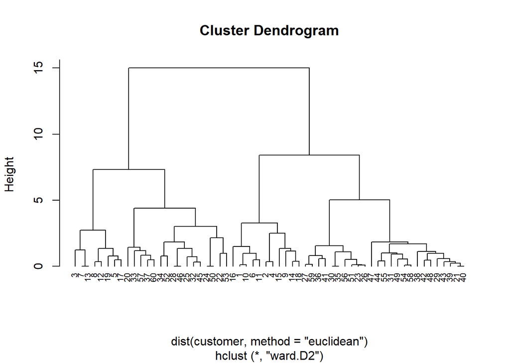

```r
plot(hc,hang = -0.01, cex = 0.7)
```

**Question 8 : Cut trees into clusters and show cluster labels for the data.**

```r
show_cluster <- cutree(hc, k=4)
show_cluster
```

```
##  [1] 1 1 2 1 2 1 2 2 1 1 1 2 2 1 1 1 2 1 2 3 4 3 4 3 3 4 4 3 4 4 4 3 3 3 4 4 3 4
## [39] 4 4 4 4 4 4 3 3 4 4 4 3 4 3 3 4 4 4 3 4 4 3
```

**Question 9 : Show the count of data within each cluster using the function table.**

```r
table(show_cluster)
```

```
## show_cluster
##  1  2  3  4
## 11  8 16 25
```

**Question 10 : Visualize the clustered data with red rectangle border.**

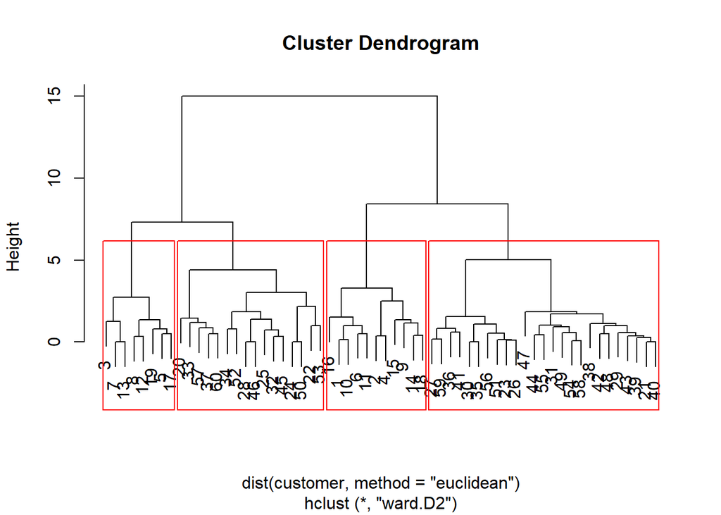

```r
plot(hc)
rect.hclust(hc,k=4, border="red")
```

**Question 11 : Hilight the cluster 2 with red rectangle border.**

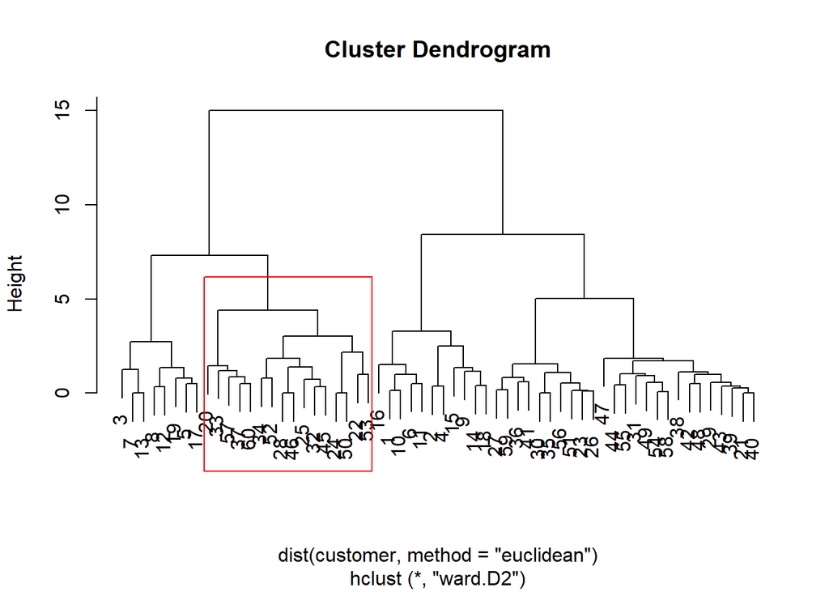

```r
plot(hc)
rect.hclust(hc,k = 4, which = 2, border = "red")
```

**Question 12 : Using the function fviz_cluster() in factoextra, visualize the result in a scatter plot: Observations are represented by points in the plot, using principal components. A frame is drawn around each cluster.**

```r
library(dendextend)
```

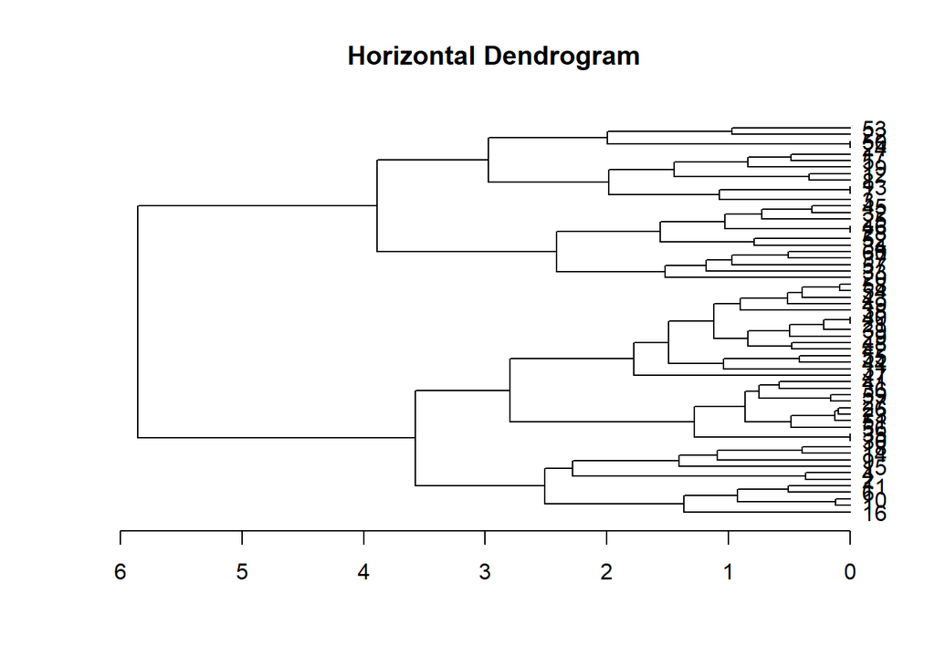

```r
dendogram <- customer %>% dist %>% hclust %>% as.dendrogram
dendogram %>%plot(horiz=TRUE, main="Horizontal Dendrogram")
```

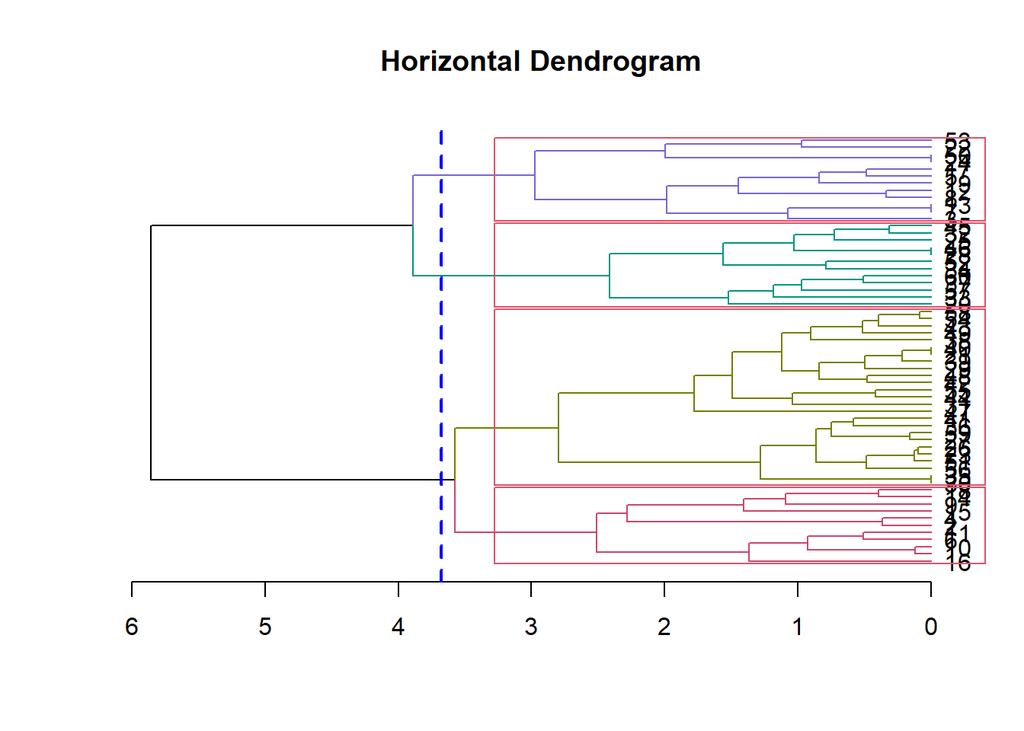

```r
#Color the branch according to the cluster it belongs to:
dendogram %>% color_branches(k=4) %>% plot(horiz=TRUE, main ="Horizontal Dendrogram")
#Add a red rectangle around the clusters:
dendogram %>% rect.dendrogram(k=4,horiz=TRUE)
#Add a line to show the tree cutting location:
abline(v = heights_per_k.dendrogram(dendogram)["4"] + .1, lwd = 2,lty = 2, col = "blue")
```

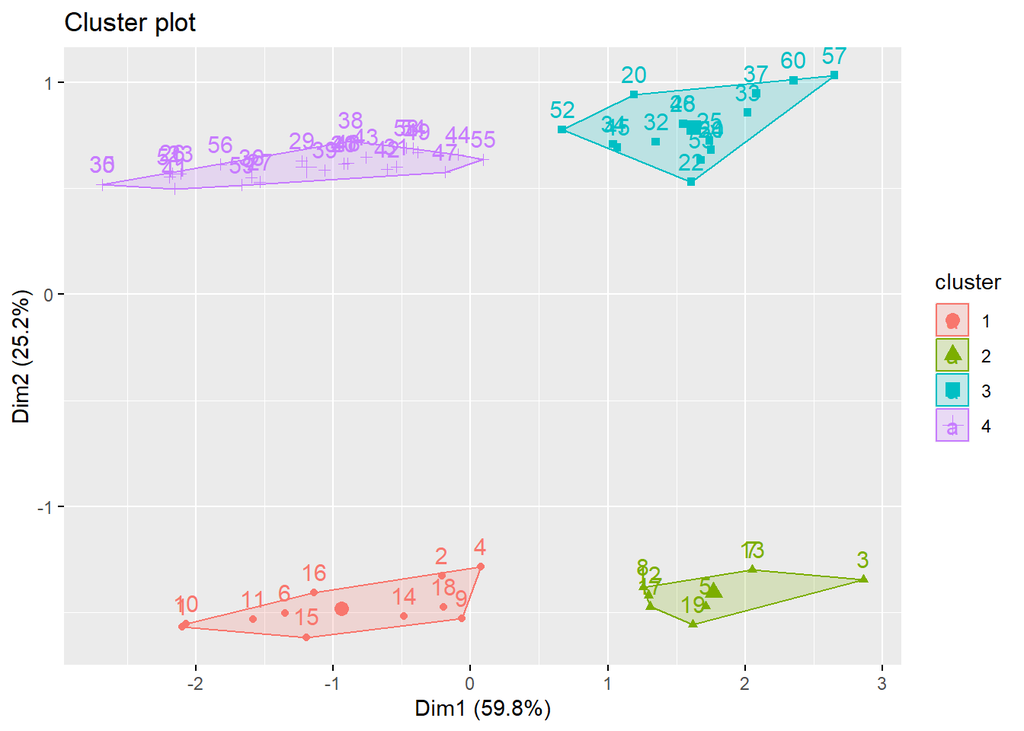

```r
fviz_cluster(list(data = customer, cluster = show_cluster))
```

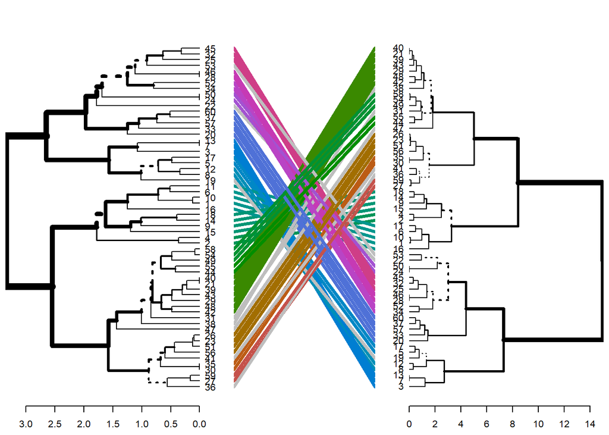

```r
#Compute two hierarchical clusterings
hc1 <- hclust((dist(customer, method="euclidean")), method="average")
hc2 <- hclust((dist(customer, method="euclidean")), method="ward.D2")

#Compute two dendograms
dendogram1 <- as.dendrogram((hc1))
dendogram2 <- as.dendrogram((hc2))

#Create a list of dendrograms
dend_list <- dendlist(dendogram1, dendogram2)

# plots two dendrograms side by side

tanglegram(dendogram1, dendogram2)
```

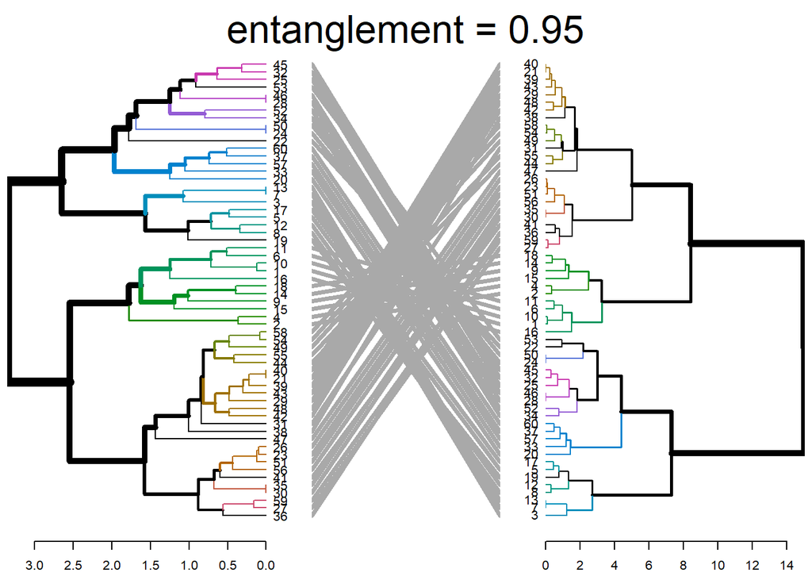

```r
#The quality measurement
tanglegram(dendogram1, dendogram2,
  highlight_distinct_edges = FALSE,
  common_subtrees_color_lines = FALSE,
  common_subtrees_color_branches = TRUE,
  main = paste("entanglement =", round(entanglement(dend_list), 2))
  )
```

**Question 15 : Compare simultaneously multiple dendrograms using the chaining operator %>% (available in dendextend) which is used to run multiple function at the same time.**

```r
library(corrplot)
# Create multiple dendrograms by chaining
dendogram1 <- customer %>% dist %>% hclust("com") %>% as.dendrogram
dendogram2 <- customer %>% dist %>% hclust("single") %>% as.dendrogram
dendogram3 <- customer %>% dist %>% hclust("ave") %>% as.dendrogram
dendogram4 <- customer %>% dist %>% hclust("centroid") %>% as.dendrogram
```

```r
# Compute correlation matrix
dend_list <- dendlist("Complete" = dendogram1, "Single" = dendogram2,
                      "Average" = dendogram3, "ward" = dendogram4)
cors <- cor.dendlist(dend_list)
# Print correlation matrix
round(cors, 2)
```

```
##          Complete Single Average ward
## Complete     1.00   0.40    0.96 0.89
## Single       0.40   1.00    0.54 0.62
## Average      0.96   0.54    1.00 0.95
## ward         0.89   0.62    0.95 1.00
```

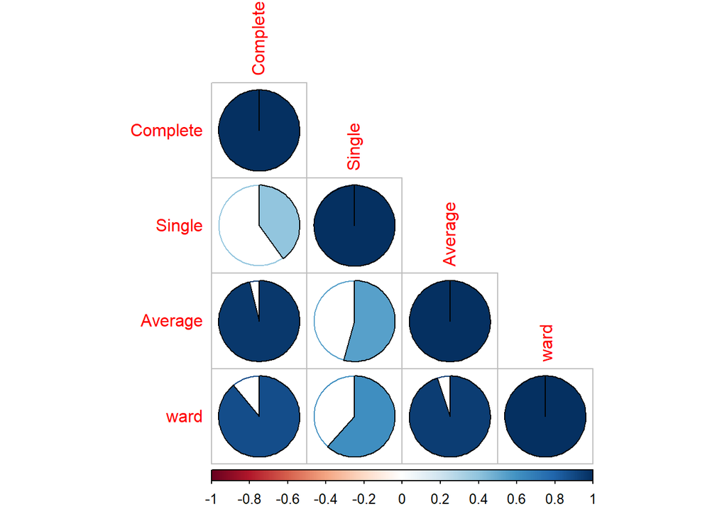

```r
# Visualize the correlation matrix using corrplot package
corrplot(cors, "pie", "lower")
```